# DACSS 603: Homework 4

Homework # 4 questions and answers for DACSS 603: Introduction to Quantitative Analysis

Megan Georges  
2022-04-05

# Part 1, Question 1:

**(SMSS 14.3, 14.4, merged & modified)**

**(Data file: house.selling.price.2 from smss R package)**

**For the house.selling.price.2 data the tables below show a correlation matrix and a model fit using four predictors of selling price.**

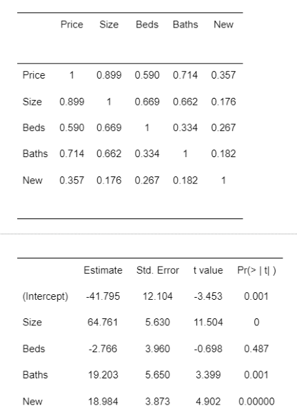

house.selling.price.2 correlation matrix and model fit using four predictors of selling price

**With these four predictors,**

**a. For backward elimination, which variable would be deleted first? Why?**

```r
data("house.selling.price.2")
head(house.selling.price.2)
```

```
      P    S Be Ba New
1  48.5 1.10  3  1   0
2  55.0 1.01  3  2   0
3  68.0 1.45  3  2   0
4 137.0 2.40  3  3   0
5 309.4 3.30  4  3   1
6  17.5 0.40  1  1   0
```

```r
PriceALL <- lm(P ~ ., data = house.selling.price.2)
summary(PriceALL)
```

```
Call:
lm(formula = P ~ ., data = house.selling.price.2)

Residuals:
    Min      1Q  Median      3Q     Max
-36.212  -9.546   1.277   9.406  71.953

Coefficients:
            Estimate Std. Error t value Pr(>|t|)
(Intercept)  -41.795     12.104  -3.453 0.000855 ***
S             64.761      5.630  11.504  < 2e-16 ***
Be            -2.766      3.960  -0.698 0.486763
Ba            19.203      5.650   3.399 0.001019 **
New           18.984      3.873   4.902  4.3e-06 ***
---
Signif. codes:  0 '***' 0.001 '**' 0.01 '*' 0.05 '.' 0.1 ' ' 1

Residual standard error: 16.36 on 88 degrees of freedom
Multiple R-squared:  0.8689,    Adjusted R-squared:  0.8629
F-statistic: 145.8 on 4 and 88 DF,  p-value: < 2.2e-16
```

For backward elimination, you fit a model using all possible explanatory values to predict the output (in this case selling price). One by one, you delete the least significant explanatory variable in the model, which would have the largest P-value. In this example, we would delete beds first, which has a P-value of 0.487.

**b. For forward selection, which variable would be added first? Why?**

With forward selection, you begin with no explanatory variables, then add one variable at a time to the model. The variable you add should be the most significant one, based on it having the lowest P-value of the group of possible explanatory variables. The book (SMSS) specifies that this is the variable with the largest t-statistic and increase in R-squared. In this example, the first variable to add to the model is Size, given its extremely small P-value (< 2e-16).

**c. Why do you think that BEDS has such a large P-value in the multiple regression model, even though it has a substantial correlation with PRICE?**

While the variable beds does have a strong correlation with price, when adding additional variables using a regression model, the relationship significantly diminishes, thus the other variables may act as a control on the bed variable.

**d. Using software with these four predictors, find the model that would be selected using each criterion:**

```r
PriceOnly <- lm(P ~ 1, data = house.selling.price.2)
PriceALL <- lm(P ~ ., data = house.selling.price.2)
Stepwise <- step(PriceOnly, direction = "both", scope = formula(PriceALL))
```

```
Start:  AIC=705.63
P ~ 1

       Df Sum of Sq    RSS    AIC
+ S     1    145097  34508 554.22
+ Ba    1     91484  88121 641.41
+ Be    1     62578 117028 667.79
+ New   1     22833 156772 694.99
<none>              179606 705.63

Step:  AIC=554.22
P ~ S

       Df Sum of Sq    RSS    AIC
+ New   1      7275  27234 534.20
+ Ba    1      4476  30033 543.30
<none>               34508 554.22
+ Be    1        40  34468 556.11
- S     1    145097 179606 705.63

Step:  AIC=534.2
P ~ S + New

       Df Sum of Sq    RSS    AIC
+ Ba    1      3550  23684 523.21
+ Be    1       589  26645 534.17
<none>               27234 534.20
- New   1      7275  34508 554.22
- S     1    129539 156772 694.99

Step:  AIC=523.21
P ~ S + New + Ba

       Df Sum of Sq   RSS    AIC
<none>              23684 523.21
+ Be    1       131 23553 524.70
- Ba    1      3550 27234 534.20
- New   1      6349 30033 543.30
- S     1     54898 78582 632.75
```

```r
summary(Stepwise)
```

```
Call:
lm(formula = P ~ S + New + Ba, data = house.selling.price.2)

Residuals:
    Min      1Q  Median      3Q     Max
-34.804  -9.496   0.917   7.931  73.338

Coefficients:
            Estimate Std. Error t value Pr(>|t|)
(Intercept)  -47.992      8.209  -5.847 8.15e-08 ***
S             62.263      4.335  14.363  < 2e-16 ***
New           18.371      3.761   4.885 4.54e-06 ***
Ba            20.072      5.495   3.653 0.000438 ***
---
Signif. codes:  0 '***' 0.001 '**' 0.01 '*' 0.05 '.' 0.1 ' ' 1

Residual standard error: 16.31 on 89 degrees of freedom
Multiple R-squared:  0.8681,    Adjusted R-squared:  0.8637
F-statistic: 195.3 on 3 and 89 DF,  p-value: < 2.2e-16
```

Using stepwise regression, the strongest model predicting selling price uses Size, New, and Bath as explanatory variables. First, I’ll compare R-squared and adjusted R-squared for the model using all explanatory variables and the model excluding Beds as a variable.

**a. R2**

```r
summary(PriceALL)
```

```
Call:
lm(formula = P ~ ., data = house.selling.price.2)

Residuals:
    Min      1Q  Median      3Q     Max
-36.212  -9.546   1.277   9.406  71.953

Coefficients:
            Estimate Std. Error t value Pr(>|t|)
(Intercept)  -41.795     12.104  -3.453 0.000855 ***
S             64.761      5.630  11.504  < 2e-16 ***
Be            -2.766      3.960  -0.698 0.486763
Ba            19.203      5.650   3.399 0.001019 **
New           18.984      3.873   4.902  4.3e-06 ***
---
Signif. codes:  0 '***' 0.001 '**' 0.01 '*' 0.05 '.' 0.1 ' ' 1

Residual standard error: 16.36 on 88 degrees of freedom
Multiple R-squared:  0.8689,    Adjusted R-squared:  0.8629
F-statistic: 145.8 on 4 and 88 DF,  p-value: < 2.2e-16
```

```r
ElimBed <- lm(P ~ . - Be, data = house.selling.price.2)
summary(ElimBed)
```

```
Call:
lm(formula = P ~ . - Be, data = house.selling.price.2)

Residuals:
    Min      1Q  Median      3Q     Max
-34.804  -9.496   0.917   7.931  73.338

Coefficients:
            Estimate Std. Error t value Pr(>|t|)
(Intercept)  -47.992      8.209  -5.847 8.15e-08 ***
S             62.263      4.335  14.363  < 2e-16 ***
Ba            20.072      5.495   3.653 0.000438 ***
New           18.371      3.761   4.885 4.54e-06 ***
---
Signif. codes:  0 '***' 0.001 '**' 0.01 '*' 0.05 '.' 0.1 ' ' 1

Residual standard error: 16.31 on 89 degrees of freedom
Multiple R-squared:  0.8681,    Adjusted R-squared:  0.8637
F-statistic: 195.3 on 3 and 89 DF,  p-value: < 2.2e-16
```

As expected, the model with the most explanatory variables (Size, New, Bed, Bath) has the highest R-squared value at 0.8689. Therefore, if you were to select a model solely based on maximizing the R-squared value, it would be: $\hat{y}$ = -41.79 + 64.76(Size) - 2.77(Beds) + 19.2(Baths) + 18.98(New)

```r
PriceALL$coefficients
```

```
(Intercept)           S          Be          Ba         New
 -41.794504   64.760606   -2.765564   19.203105   18.984237
```

**b. Adjusted R2**

However, if you were to select a model based on adjusted R-squared, which accounts for R-squared’s upward bias when adding more variables, the best model for predicting selling price would exclude Beds and use Size, Baths, and New as explanatory variables. The adjusted R-squared value see a slight increase when Beds is removed (from 0.8629 to 0.8637). The model would be: $\hat{y}$ = -47.99 + 62.26(Size) + 20.07(Baths) + 18.37(New)

```r
ElimBed$coefficients
```

```
(Intercept)           S          Ba         New
  -47.99179    62.26268    20.07203    18.37096
```

**c. PRESS**

```r
MPV::PRESS(PriceALL)
```

```
[1] 28390.22
```

```r
MPV::PRESS(ElimBed)
```

```
[1] 27860.05
```

When considering PRESS, a smaller PRESS value indicates a better predictive model. Comparing the PRESS value of the model with all variables and the model excluding Bed, the PRESS values would lead us to select the model with Size, Baths, and New as variables for predicting selling price.

**d. AIC**

```r
AIC(PriceALL)
```

```
[1] 790.6225
```

```r
AIC(ElimBed)
```

```
[1] 789.1366
```

When considering the AIC for both models, the value is slightly lower for the model that excludes Bed as a variable. Therefore, the AIC would lead us to use the model with Size, Baths, and New as explanatory variables to predicting selling price.

**e. BIC**

```r
BIC(PriceALL)
```

```
[1] 805.8181
```

```r
BIC(ElimBed)
```

```
[1] 801.7996
```

Lastly, like AIC, the BIC value is lower for the model that excludes Bed as a variable. Once again, we’d select the model that uses Size, Baths, and New as explanatory variables to predict selling price.

# Part 1, Question 2:

**(Data file: trees from base R)** **From the documentation: “This data set provides measurements of the diameter, height and volume of timber in 31 felled black cherry trees. Note that the diameter (in inches) is erroneously labelled Girth in the data. It is measured at 4 ft 6 in above the ground.”**

**Tree volume estimation is a big deal, especially in the lumber industry. Use the trees data to build a basic model of tree volume prediction. In particular,**

```r
data("trees")
head(trees)
```

```
  Girth Height Volume
1   8.3     70   10.3
2   8.6     65   10.3
3   8.8     63   10.2
4  10.5     72   16.4
5  10.7     81   18.8
6  10.8     83   19.7
```

**a. fit a multiple regression model with the Volume as the outcome and Girth and Height as the explanatory variables**

```r
VOL <- lm(Volume ~ Girth + Height, data = trees)
summary(VOL)
```

```
Call:
lm(formula = Volume ~ Girth + Height, data = trees)

Residuals:
    Min      1Q  Median      3Q     Max
-6.4065 -2.6493 -0.2876  2.2003  8.4847

Coefficients:
            Estimate Std. Error t value Pr(>|t|)
(Intercept) -57.9877     8.6382  -6.713 2.75e-07 ***
Girth         4.7082     0.2643  17.816  < 2e-16 ***
Height        0.3393     0.1302   2.607   0.0145 *
---
Signif. codes:  0 '***' 0.001 '**' 0.01 '*' 0.05 '.' 0.1 ' ' 1

Residual standard error: 3.882 on 28 degrees of freedom
Multiple R-squared:  0.948, Adjusted R-squared:  0.9442
F-statistic:   255 on 2 and 28 DF,  p-value: < 2.2e-16
```

E(Volume) = -57.99 + 4.71(Girth) + 0.34(Height)

**b. Run regression diagnostic plots on the model. Based on the plots, do you think any of the regression assumptions is violated?**

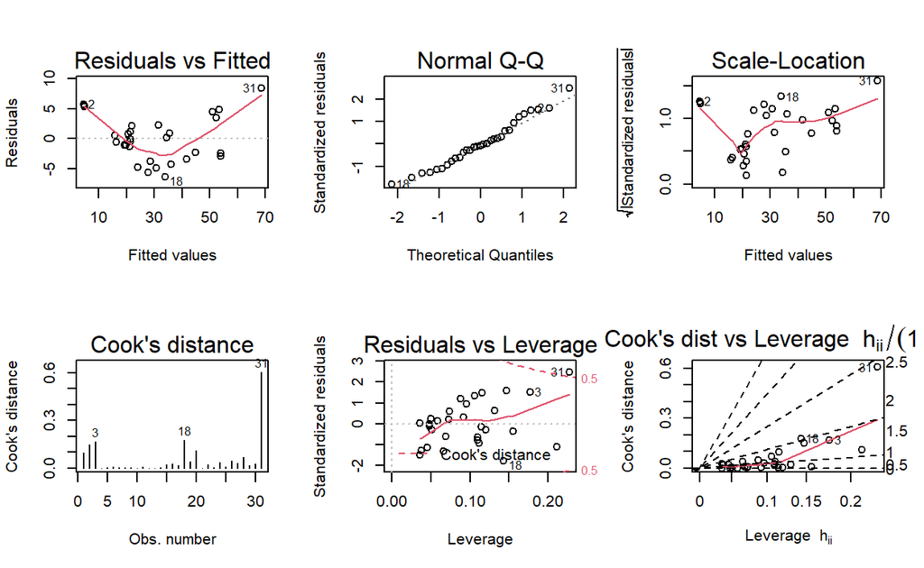

```r
par(mfrow = c(2, 3))
plot(VOL, which = 1:6)
```

Based on the residuals vs. fitted values plot, the central points appear to roughly bounce randomly above and below 0, but the lowest and highest point appear to be very influential residuals. The red line should be flat along 0 horizontally, but it is U-shaped. This curvature may suggest a violation in the linearity assumption.

With the normal Q-Q plot, it’s difficult to confidently say that the assumption of normality appears to be violated. The points generally run along the trend-line, but they do deviate above the line for the higher points. It’s a noteworthy deviation, but it’s difficult to make a certain decision based on the plot.

In the scale-location plot, the line is not horizontal (the trend decreases then increases), thus suggesting a violation in the assumption of constant variance.

Cook’s distance (as seen in the cook’s distance and residuals vs. leverage plots) suggests that the 31st observation is above the threshold (4/n or red dashed line), meaning it is too influential as one observation.

# Part 1, Question 3:

**(inspired by ALR 9.16) (Data file: florida in alr R package)**

**In the 2000 election for U.S. president, the counting of votes in Florida was controversial. In Palm Beach County in south Florida, for example, voters used a so-called butterfly ballot. Some believe that the layout of the ballot caused some voters to cast votes for Buchanan when their intended choice was Gore.**

**The data has variables for the number of votes for each candidate—Gore, Bush, and Buchanan. Run a simple linear regression model where the Buchanan vote is the outcome and the Bush vote is the explanatory variable. Produce the regression diagnostic plots. Is Palm Beach County an outlier based on the diagnostic plots? Why or why not?**

```r
data("florida")
head(florida)
```

```
           Gore   Bush Buchanan
ALACHUA   47300  34062      262
BAKER      2392   5610       73
BAY       18850  38637      248
BRADFORD   3072   5413       65
BREVARD   97318 115185      570
BROWARD  386518 177279      789
```

```r
SLR <- lm(Buchanan ~ Bush, data = florida)
summary(SLR)
```

```
Call:
lm(formula = Buchanan ~ Bush, data = florida)

Residuals:
    Min      1Q  Median      3Q     Max
-907.50  -46.10  -29.19   12.26 2610.19

Coefficients:
             Estimate Std. Error t value Pr(>|t|)
(Intercept) 4.529e+01  5.448e+01   0.831    0.409
Bush        4.917e-03  7.644e-04   6.432 1.73e-08 ***
---
Signif. codes:  0 '***' 0.001 '**' 0.01 '*' 0.05 '.' 0.1 ' ' 1

Residual standard error: 353.9 on 65 degrees of freedom
Multiple R-squared:  0.3889,    Adjusted R-squared:  0.3795
F-statistic: 41.37 on 1 and 65 DF,  p-value: 1.727e-08
```

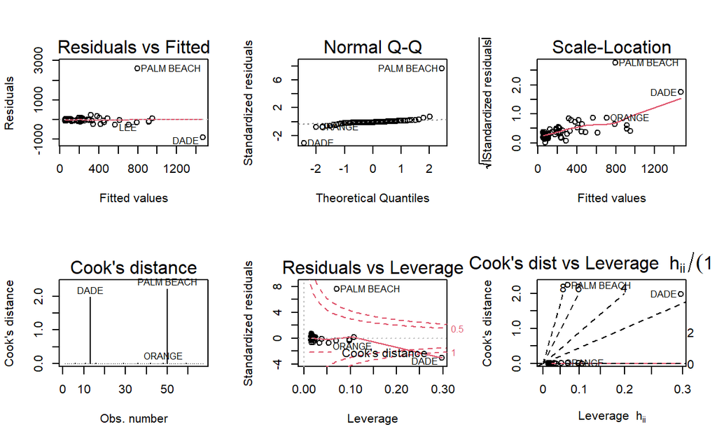

```r
par(mfrow = c(2, 3))
plot(SLR, which = 1:6)
```

Based on the diagnostic plots, Palm Beach County is an outlier. First, when looking at the residuals vs fitted plot, the Palm Beach County residual is very large (over 2,000). When referring to the summary of the simple regression model, the third quartile for residuals is 12.26, yet the max is 2610.19. This is a significant jump and indicative of the value being an outlier. The normal Q-Q plot also indicates that the residuals for the model are generally normal except for the Palm Beach County residual, as it greatly deviates from the line in the plot. The Cook’s distance plot shows two points that may be of concern (as outliers) if you follow the metric of observations scoring over 1, which are DADE and Palm Beach at about 2 (or following the 4/n metric instead, with 67 observations (4/67 = .06)). The residuals and leverages plot shows the Palm Beach County standardized residual value beyond the dashed line indicating Cook’s distance. This also suggests that the observation is an outlier and the observation has the potential to influence the regression model.

# Part 2, Question 1:

**What is your research question for the final project?**

Does a relationship exist between political affiliation and support for alternatives to imprisonment for non-violent drug offenders?

# Part 2, Question 2:

**What is your hypothesis (i.e. an answer to the research question) that you want to test?**

There is no relationship between political affiliation and support for alternatives to imprisonment for non-violent drug offenders.

# Part 2, Question 3:

**Present some exploratory analysis. In particular:**

**a. Numerically summarize (e.g. with the summary() function) the variables of interest (the outcome, the explanatory variable, the control variables).**

**Information on Data Source:**

- “2020 Taking America’s Pulse Survey, Designed by Students at Cornell”
- Organization: National Opinion Research Center (NORC)
- Sample Size: 1159 US Adults
- October 2020

```r
TAP <- suppressMessages(read_csv("../../DACSS 603/TAP_data.csv"))

Vars <- select_(TAP, "caseid", "partyid5", "q9")
```

**Outcome Variable:** ‘q9’ - “Do you agree, disagree, or neither agree nor disagree with the following statement: The United States Federal Courts should pursue an alternative to imprisonment, such as treatment programs, probation, fines, or community service, for non-violent drug offenders.” 1 Strongly agree 2 Somewhat agree 3 Neither agree nor disagree 4 Somewhat disagree 5 Strongly disagree

```r
Vars$q9[Vars$q9 == "Strongly agree"] <- "1"
Vars$q9[Vars$q9 == "Somewhat agree"] <- "2"
Vars$q9[Vars$q9 == "Neither agree nor disagree"] <- "3"
Vars$q9[Vars$q9 == "Somewhat disagree"] <- "4"
Vars$q9[Vars$q9 == "Strongly disagree"] <- "5"

Vars <- Vars %>%
  filter(!str_detect(`q9`, "SKIPPED ON WEB"))

Vars$q9 <- as.numeric(Vars$q9)

summary(Vars$q9)
```

```
   Min. 1st Qu.  Median    Mean 3rd Qu.    Max.
  1.000   1.000   2.000   2.017   3.000   5.000
```

**Explanatory Variable:** ‘partyid5’ - party identification with 5 options 1 Democrat 2 Lean Democrat 3 Don’t Lean/Independent/None 4 Lean Republic 5 Republican

```r
Vars$partyid5[Vars$partyid5 == "Democrat"] <- "1"
Vars$partyid5[Vars$partyid5 == "Lean Democrat"] <- "2"
Vars$partyid5[Vars$partyid5 == "Don't Lean/Independent/None"] <- "3"
Vars$partyid5[Vars$partyid5 == "Lean Republican"] <- "4"
Vars$partyid5[Vars$partyid5 == "Republican"] <- "5"
Vars$partyid5[Vars$partyid5 == "Unknown"] <- "NA"

Vars <- Vars %>%
  filter(!str_detect(`partyid5`, "NA"))
Vars$partyid5 <- as.numeric(Vars$partyid5)

summary(Vars$partyid5)
```

```
   Min. 1st Qu.  Median    Mean 3rd Qu.    Max.
  1.000   1.000   3.000   2.777   5.000   5.000
```

I Still haven’t determined control variables to include/consider.

**b. Plot the relationships between key variables. You can do this any way you want, but one straightforward way of doing this would be with the pairs() function or other scatter plots / box plots. Interpret what you see.**

```r
kable(Vars, col.names = c("Case ID", "Party ID", "Q9 Response"), align = c('c', 'c', 'c'), caption = "QUANTIFIED DATA: Political Affiliation and Response to Q9 - courts should pursue alternatives to imprisonment for non-violent drug offenses") %>%
  kable_styling() %>%
  scroll_box(width = "100%", height = "400px")
```

Table 1: QUANTIFIED DATA: Political Affiliation and Response to Q9 - courts should pursue alternatives to imprisonment for non-violent drug offenses

| Case ID | Party ID | Q9 Response |
| --- | --- | --- |
| 53 | 5 | 5 |
| 55 | 5 | 3 |
| 56 | 3 | 2 |
| 57 | 3 | 2 |
| 58 | 2 | 1 |
| 62 | 2 | 1 |
| 64 | 4 | 4 |
| 67 | 1 | 1 |
| 71 | 3 | 1 |
| 80 | 5 | 2 |
| 85 | 5 | 2 |
| 87 | 1 | 1 |
| 93 | 1 | 2 |
| 94 | 5 | 3 |
| 95 | 3 | 1 |
| 97 | 1 | 1 |
| 99 | 3 | 1 |
| 100 | 5 | 5 |
| 102 | 4 | 3 |
| 106 | 4 | 3 |
| 111 | 2 | 2 |
| 112 | 1 | 1 |
| 114 | 3 | 5 |
| 115 | 5 | 1 |
| 121 | 5 | 2 |
| 126 | 1 | 1 |
| 133 | 1 | 4 |
| 138 | 1 | 3 |
| 139 | 4 | 4 |
| 143 | 1 | 1 |

[output cut: 1114 more lines]

```r
RawData <- select_(TAP, "caseid", "partyid5", "q9")
kable(RawData, col.names = c("Case ID", "Party ID", "Q9 Response"), align = c('c', 'c', 'c'), caption = "RAW DATA: Political Affiliation and Response to Q9 - courts should pursue alternatives to imprisonment for non-violent drug offenses") %>%
  kable_styling() %>%
  scroll_box(width = "100%", height = "400px")
```

Table 1: RAW DATA: Political Affiliation and Response to Q9 - courts should pursue alternatives to imprisonment for non-violent drug offenses

| Case ID | Party ID | Q9 Response |
| --- | --- | --- |
| 53 | Republican | Strongly disagree |
| 55 | Republican | Neither agree nor disagree |
| 56 | Don’t Lean/Independent/None | Somewhat agree |
| 57 | Don’t Lean/Independent/None | Somewhat agree |
| 58 | Lean Democrat | Strongly agree |
| 60 | Unknown | Strongly agree |
| 62 | Lean Democrat | Strongly agree |
| 64 | Lean Republican | Somewhat disagree |
| 67 | Democrat | Strongly agree |
| 71 | Don’t Lean/Independent/None | Strongly agree |
| 80 | Republican | Somewhat agree |
| 85 | Republican | Somewhat agree |
| 87 | Democrat | Strongly agree |
| 93 | Democrat | Somewhat agree |
| 94 | Republican | Neither agree nor disagree |
| 95 | Don’t Lean/Independent/None | Strongly agree |
| 97 | Democrat | Strongly agree |
| 99 | Don’t Lean/Independent/None | Strongly agree |
| 100 | Republican | Strongly disagree |
| 102 | Lean Republican | Neither agree nor disagree |
| 106 | Lean Republican | Neither agree nor disagree |
| 111 | Lean Democrat | Somewhat agree |
| 112 | Democrat | Strongly agree |
| 114 | Don’t Lean/Independent/None | Strongly disagree |
| 115 | Republican | Strongly agree |
| 121 | Republican | Somewhat agree |
| 126 | Democrat | Strongly agree |
| 133 | Democrat | Somewhat disagree |
| 138 | Democrat | Neither agree nor disagree |
| 139 | Lean Republican | Somewhat disagree |

[output cut: 1129 more lines]

```r
RawData %>%
  group_by(partyid5) %>%
  summarise(counts = n())
```

```
# A tibble: 6 x 2
  partyid5                    counts
  <chr>                        <int>
1 Democrat                       431
2 Don't Lean/Independent/None    146
3 Lean Democrat                  139
4 Lean Republican                121
5 Republican                     313
6 Unknown                          9
```

```r
RawData %>%
  group_by(q9) %>%
  summarise(counts = n())
```

```
# A tibble: 6 x 2
  q9                         counts
  <chr>                       <int>
1 Neither agree nor disagree    172
2 SKIPPED ON WEB                  6
3 Somewhat agree                383
4 Somewhat disagree              74
5 Strongly agree                468
6 Strongly disagree              56
```

```r
counts <- RawData %>%
  filter(!str_detect(partyid5, "Unknown")) %>%
  filter(!str_detect(q9, "SKIPPED ON WEB")) %>%
  group_by(partyid5, q9) %>%
  summarise(counts = n())

kable(counts, col.names = c("Party ID", "Q9 Response", "Counts"), caption = "Frequency of Responses to Q9 (support for alternatives to imprisonment) by Political ID") %>%
  kable_styling() %>%
  scroll_box(width = "100%", height = "400px")
```

Table 2: Frequency of Responses to Q9 (support for alternatives to imprisonment) by Political ID

| Party ID | Q9 Response | Counts |
| --- | --- | --- |
| Democrat | Neither agree nor disagree | 47 |
| Democrat | Somewhat agree | 113 |
| Democrat | Somewhat disagree | 10 |
| Democrat | Strongly agree | 255 |
| Democrat | Strongly disagree | 4 |
| Don’t Lean/Independent/None | Neither agree nor disagree | 37 |
| Don’t Lean/Independent/None | Somewhat agree | 50 |
| Don’t Lean/Independent/None | Somewhat disagree | 6 |
| Don’t Lean/Independent/None | Strongly agree | 44 |
| Don’t Lean/Independent/None | Strongly disagree | 8 |
| Lean Democrat | Neither agree nor disagree | 9 |
| Lean Democrat | Somewhat agree | 46 |
| Lean Democrat | Somewhat disagree | 3 |
| Lean Democrat | Strongly agree | 73 |
| Lean Democrat | Strongly disagree | 8 |
| Lean Republican | Neither agree nor disagree | 28 |
| Lean Republican | Somewhat agree | 41 |
| Lean Republican | Somewhat disagree | 13 |
| Lean Republican | Strongly agree | 35 |
| Lean Republican | Strongly disagree | 3 |
| Republican | Neither agree nor disagree | 48 |
| Republican | Somewhat agree | 130 |
| Republican | Somewhat disagree | 42 |
| Republican | Strongly agree | 59 |
| Republican | Strongly disagree | 32 |

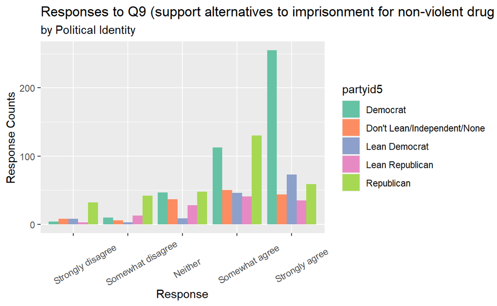

```r
counts$q9[counts$q9 == "Neither agree nor disagree"] <- "Neither"

responses <- c("Strongly disagree", "Somewhat disagree", "Neither", "Somewhat agree", "Strongly agree")
ggplot(data = counts, mapping = aes(x = q9, y = counts, fill = partyid5)) +
  geom_bar(stat = "identity", position = position_dodge()) +
  labs(title = "Responses to Q9 (support alternatives to imprisonment for non-violent drug offenses)",
       subtitle = "by Political Identity", x = "Response", y = "Response Counts", xlab(c("Not Tough Enough", "About Right", "Too Tough", "No Opinion"))) +
  scale_x_discrete(limits = responses) +
  scale_fill_brewer(palette = "Set2") +
  theme(axis.text.x = element_text(angle = 30, vjust = .3, hjust = .3))
```

Based on the initial bargraph (not considering any control variables), most Democrats appear to be supportive to alternatives to imprisonment for non-violent drug offenses and out of those strongly agreeing with the Q9 concept, most are Democrats, while Republicans are more spread out across support/not support of the concept.